# 1. Importing necessary libraries

```python
import csv
import numpy as np
import pandas as pd
import matplotlib.pyplot as plt
```

# 2. Loading and reading csv data

```python
data = pd.read_csv('C:/Users/sindi/Downloads/SURVEY.csv', sep=';')
```

# 3. View of data frame

```python
data.head()
```

|  | Gender | Age_Group | Study_Level | School | Location | Home_Computer | Home_Internet | Moodle_Training | Training_Time | Moodle_Access | ... | STU_LEC_TUT_INTERACT | SAFE_FOR_QUIZZES_AND_SUBMIT | POTENTIAL_FOR_CONTENT_USE | REMEMBER_LOT_INFO | DIFFICULT_ERR_RECOV | HELP_FOR_EVERY_TASK | STRUGGLE_AFTER_NOT_USE | DIFFICULT_TO_ADAPT | LIMITED_COMP_KNOWLEDGE | SOME_LEC_DONT_USE |
| --- | --- | --- | --- | --- | --- | --- | --- | --- | --- | --- | --- | --- | --- | --- | --- | --- | --- | --- | --- | --- | --- |
| 0 | M | 18-23 | 1st year | HUM | ON-CAMP | YES | YES | NO | 0 | Daily | ... | STRONGLY_AGR | STRONGLY_AGR | STRONGLY_AGR | STRONGLY_DISA | STRONGLY_DISA | STRONGLY_DISA | AGREE | STRONGLY_DISA | STRONGLY_DISA | STRONGLY_AGR |
| 1 | F | 18-23 | 1st year | HUM | ON-CAMP | NO | YES | NO | 0 | Daily | ... | STRONGLY_AGR | STRONGLY_AGR | STRONGLY_AGR | STRONGLY_DISA | STRONGLY_DISA | STRONGLY_DISA | AGREE | STRONGLY_DISA | STRONGLY_DISA | STRONGLY_AGR |
| 2 | F | 30-35 | 1st year | HUM | ON-CAMP | NO | YES | NO | 0 | Daily | ... | STRONGLY_AGR | STRONGLY_AGR | STRONGLY_AGR | STRONGLY_DISA | STRONGLY_DISA | STRONGLY_DISA | AGREE | STRONGLY_DISA | STRONGLY_DISA | STRONGLY_AGR |
| 3 | M | 30-35 | 1st year | HUM | ON-CAMP | NO | YES | YES | >60 | Daily | ... | STRONGLY_AGR | STRONGLY_AGR | STRONGLY_AGR | DISAGREE | DISAGREE | STRONGLY_DISA | DISAGREE | DISAGREE | STRONGLY_DISA | STRONGLY_AGR |
| 4 | M | 24-29 | POSTGRAD | NAS | HOME | NO | YES | NO | 0 | ONCE/WEEK | ... | STRONGLY_AGR | STRONGLY_AGR | STRONGLY_AGR | STRONGLY_DISA | STRONGLY_DISA | STRONGLY_DISA | AGREE | STRONGLY_DISA | STRONGLY_DISA | STRONGLY_AGR |

5 rows × 43 columns

#### The output above show us the view and the structure of our dataframe

# 4. Shape of the data

```python
data.shape
```

```
(92, 43)
```

#### The output above tells us that our dataframe has 92 rows and 43 columns

# 5. Unique values and data types

```python
#total of all unique values for each field
def unique_col_values(df):
    for column in df:
        print("{} | {} | {}".format(df[column].name, len(df[column].unique()),
                                    df[column].dtype))

unique_col_values(data)
```

```
Gender | 2 | object
Age_Group | 3 | object
Study_Level | 5 | object
School | 4 | object
Location | 3 | object
Home_Computer | 2 | object
Home_Internet | 2 | object
Moodle_Training | 2 | object
Training_Time | 4 | object
Moodle_Access | 2 | object
Moodle_For_All | 2 | object
Moodle_experience | 2 | object
SUBMITTING | 2 | object
INTERATING | 2 | object
COURSE_MAT | 2 | object
DISCUSSIONS | 2 | object
ANNOUNCEMENTS | 2 | object
COMFORTABLE | 4 | object
SUPPORT | 5 | object
EASY_TO_USE | 3 | object
DIFFICULT_TO_USE | 4 | object
USER_FRIENDLY | 4 | object
HELPFUL_ERR_MSG | 5 | object
CONFUSING_ERR_MSG | 5 | object
SATISFIED | 4 | object
GOOD_MOBILE_FEATURES_INTERFACES | 5 | object
GOOD_DESKTOP_FEATURES_INTERFACES | 5 | object
INFO_ORGAIZED | 5 | object
INSUFFICIENT_FEATURES | 5 | object
MOSTLY_USED_TO_UPLOAD | 4 | object
ANYTIME_ACCESS | 5 | object
EASE_AND_QUICK_SHARING | 4 | object
OWN_PACE_LEARNING | 4 | object
STU_LEC_TUT_INTERACT | 4 | object
SAFE_FOR_QUIZZES_AND_SUBMIT | 4 | object
POTENTIAL_FOR_CONTENT_USE | 4 | object
REMEMBER_LOT_INFO | 5 | object
DIFFICULT_ERR_RECOV | 5 | object
HELP_FOR_EVERY_TASK | 4 | object
STRUGGLE_AFTER_NOT_USE | 5 | object
DIFFICULT_TO_ADAPT | 5 | object
LIMITED_COMP_KNOWLEDGE | 5 | object
SOME_LEC_DONT_USE | 5 | object
```

#### The output above is telling us how many unique values does each column have, and also the data types of values in each column.

# 6. Respondents' demographics

## 6.1 Gender

```python
data['Gender'].value_counts(ascending=True)
```

```
M    33
F    59
Name: Gender, dtype: int64
```

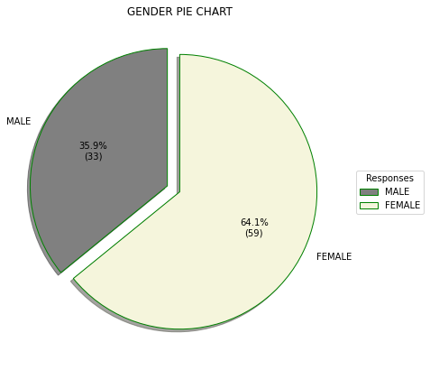

```python
responses = ['MALE', 'FEMALE']
temp_data = [33, 59]

explode = (0.1, 0.0)
colors = ("grey", "beige")
wp = {'linewidth':1, 'edgecolor':"green"}

def func(pct, allval):
    absolute = int(pct/100.*np.sum(allval))
    return "{:.1f}%\n({:d})".format(pct, absolute)

fig, ax = plt.subplots(figsize = (10, 7))
wedges, texts, autotexts = ax.pie(temp_data,
                                  autopct = lambda pct: func(pct, temp_data),
                                  explode = explode,
                                  labels = responses,
                                  shadow = True,
                                  colors = colors,
                                  startangle = 90,
                                  wedgeprops = wp,
                                  textprops = dict(color = "BLACK"))

ax.legend(wedges, responses,
          title = "Responses",
          loc = "center left",
          bbox_to_anchor = (1, 0.5))
ax.set_title("GENDER PIE CHART")
plt.show()
```

#### It is observed from the outputs above that the Gender column consists of 33 (35.9%) males and 59 (64.1%) females.

## 6.2 Age Group

```python
data['Age_Group'].value_counts(ascending=True)
```

```
30-35     9
24-29    15
18-23    68
Name: Age_Group, dtype: int64
```

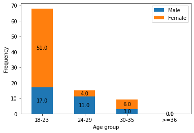

```python
df = pd.DataFrame({
    'Male': [17, 11, 3, 0],
    'Female': [51, 4, 6, 0]
 })

Class = ['18-23', '24-29', '30-35', '>=36']
ax = df.plot(stacked=True, kind='bar')

for bar in ax.patches:
    height = bar.get_height()
    width = bar.get_width()
    x = bar.get_x()
    y = bar.get_y()
    label_text = height
    label_x = x + width / 2
    label_y = y + height / 2
    ax.text(label_x, label_y, label_text, ha='center',
            va='center')

ax.set_xticklabels(Class,rotation='horizontal')

plt.xlabel("Age group")
plt.ylabel("Frequency")

plt.show()
```

#### The outputs above tell us about the frequencies of respondents per age group and based on gender.

## 6.3 Study level

```python
data['Study_Level'].value_counts(ascending=True)
```

```
4th year     3
POSTGRAD     6
3rd year    18
2nd year    18
1st year    47
Name: Study_Level, dtype: int64
```

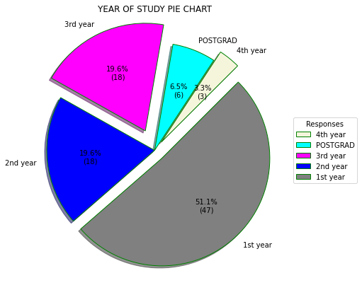

```python
responses = ['4th year', 'POSTGRAD', '3rd year', '2nd year', '1st year']
temp_data = [3, 6, 18, 18, 47]

explode = (0.1, 0.0, 0.2, 0.0, 0.1)
colors = ("beige", "cyan", "magenta", "blue", "grey")
wp = {'linewidth':1, 'edgecolor':"green"}

def func(pct, allval):
    absolute = int(pct/100.*np.sum(allval)+1)
    return "{:.1f}%\n({:d})".format(pct, absolute)

fig, ax = plt.subplots(figsize = (10, 7))
wedges, texts, autotexts = ax.pie(temp_data,
                                  autopct = lambda pct: func(pct, temp_data),
                                  explode = explode,
                                  labels = responses,
                                  shadow = True,
                                  colors = colors,
                                  startangle = 45,
                                  wedgeprops = wp,
                                  textprops = dict(color = "black"))

ax.legend(wedges, responses,
          title = "Responses",
          loc = "center left",
          bbox_to_anchor = (1, 0.5))
ax.set_title("YEAR OF STUDY PIE CHART")
plt.show()
```

#### The outputs above tell us about the frequencies and percentages of respondents per level of stduy.

# 6.4 Schools

```python
data['School'].value_counts(ascending=True)
```

```
EMS    19
HUM    23
NAS    25
EDU    25
Name: School, dtype: int64
```

[figure not shown]

```python
responses = ['EMS', 'HUM', 'NAS', 'EDU']
temp_data = [19, 23, 25, 25]

explode = (0.1, 0.0, 0.2, 0.0)
colors = ("blue", "orange", "green", "yellow")
wp = {'linewidth':1, 'edgecolor':"green"}

def func(pct, allval):
    absolute = int(pct/100.*np.sum(allval))
    return "{:.1f}%\n({:d})".format(pct, absolute)

fig, ax = plt.subplots(figsize = (10, 7))
wedges, texts, autotexts = ax.pie(temp_data,
                                  autopct = lambda pct: func(pct+1, temp_data),
                                  explode = explode,
                                  labels = responses,
                                  shadow = True,
                                  colors = colors,
                                  startangle = 90,
                                  wedgeprops = wp,
                                  textprops = dict(color = "black"))

ax.legend(wedges, responses,
          title = "Responses",
          loc = "center left",
          bbox_to_anchor = (1, 0.5))
#ax.set_title("SCHOOLS PIE CHART")
plt.show()
```

#### The ouputs above tell us about the frequencies and percentages of the respondents per school.

## 6.5 Study location

```python
data['Location'].value_counts(ascending=True)
```

```
HOME         7
OFF-CAMP    10
ON-CAMP     75
Name: Location, dtype: int64
```

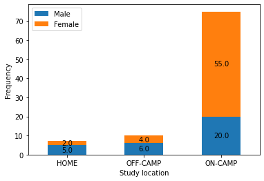

```python
df = pd.DataFrame({
    'Male': [5, 6, 20],
    'Female': [2, 4, 55]
 })

Class = ['HOME', 'OFF-CAMP', 'ON-CAMP']
ax = df.plot(stacked=True, kind='bar')

for bar in ax.patches:
    height = bar.get_height()
    width = bar.get_width()
    x = bar.get_x()
    y = bar.get_y()
    label_text = height
    label_x = x + width / 2
    label_y = y + height / 2
    ax.text(label_x, label_y, label_text, ha='center',
            va='center')

ax.set_xticklabels(Class,rotation='horizontal')

plt.xlabel("Study location")
plt.ylabel("Frequency")

plt.show()
```

#### The outputs above tell us about the frequencies of the respondents per study location base on their gender.

## 6.6 Computer at home

```python
data['Home_Computer'].value_counts(ascending=True)
```

```
NO     40
YES    52
Name: Home_Computer, dtype: int64
```

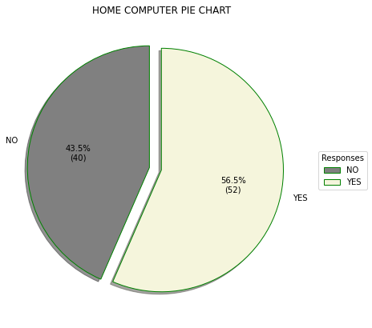

```python
responses = ['NO', 'YES']
temp_data = [40, 52]

explode = (0.1, 0.0)
colors = ("grey", "beige")
wp = {'linewidth':1, 'edgecolor':"green"}

def func(pct, allval):
    absolute = int(pct/100.*np.sum(allval)+1)
    return "{:.1f}%\n({:d})".format(pct, absolute)

fig, ax = plt.subplots(figsize = (10, 7))
wedges, texts, autotexts = ax.pie(temp_data,
                                  autopct = lambda pct: func(pct, temp_data),
                                  explode = explode,
                                  labels = responses,
                                  shadow = True,
                                  colors = colors,
                                  startangle = 90,
                                  wedgeprops = wp,
                                  textprops = dict(color = "black"))

ax.legend(wedges, responses,
          title = "Responses",
          loc = "center left",
          bbox_to_anchor = (1, 0.5))
ax.set_title("HOME COMPUTER PIE CHART")
plt.show()
```

#### The outputs above tell us about the frequencies and percentages of the respondents who have and do not have computers at home, where home refers to thei study locations.

## 6.7 Internet at home

```python
data["Home_Internet"].value_counts(ascending=True)
```

```
NO     23
YES    69
Name: Home_Internet, dtype: int64
```

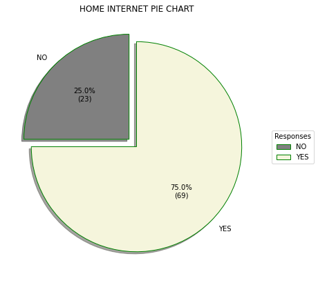

```python
responses = ['NO', 'YES']
temp_data = [23, 69]

explode = (0.1, 0.0)
colors = ("grey", "beige")
wp = {'linewidth':1, 'edgecolor':"green"}

def func(pct, allval):
    absolute = int(pct/100.*np.sum(allval))
    return "{:.1f}%\n({:d})".format(pct, absolute)

fig, ax = plt.subplots(figsize = (10, 7))
wedges, texts, autotexts = ax.pie(temp_data,
                                  autopct = lambda pct: func(pct, temp_data),
                                  explode = explode,
                                  labels = responses,
                                  shadow = True,
                                  colors = colors,
                                  startangle = 90,
                                  wedgeprops = wp,
                                  textprops = dict(color = "black"))

ax.legend(wedges, responses,
          title = "Responses",
          loc = "center left",
          bbox_to_anchor = (1, 0.5))
ax.set_title("HOME INTERNET PIE CHART")
plt.show()
```

#### The outputs above tell us about the frequencies and percentages of the respondents who have and do not have access to the at home, where home refers to thei study locations.

## 6.8 Moodle Training

```python
data['Moodle_Training'].value_counts(ascending=True)
```

```
NO     41
YES    51
Name: Moodle_Training, dtype: int64
```

[figure not shown]

```python
responses = ['NO', 'YES']
temp_data = [41, 51]

explode = (0.1, 0.0)
colors = ("grey", "beige")
wp = {'linewidth':1, 'edgecolor':"green"}

def func(pct, allval):
    absolute = int(pct/100.*np.sum(allval))
    return "{:.1f}%\n({:d})".format(pct, absolute)

fig, ax = plt.subplots(figsize = (10, 7))
wedges, texts, autotexts = ax.pie(temp_data,
                                  autopct = lambda pct: func(pct+1, temp_data),
                                  explode = explode,
                                  labels = responses,
                                  shadow = True,
                                  colors = colors,
                                  startangle = 90,
                                  wedgeprops = wp,
                                  textprops = dict(color = "black"))

ax.legend(wedges, responses,
          title = "Responses",
          loc = "center left",
          bbox_to_anchor = (1, 0.5))
ax.set_title("MOODLE TRAINING PIE CHART")
plt.show()
```

#### The outputs above tell us about the frequencies and percentages of the respondents who did and did not receive Moodle training.

## 6.9 Training duration

```python
data['Training_Time'].value_counts(ascending=True)
```

```
<30       5
>60      18
30-60    28
0        41
Name: Training_Time, dtype: int64
```

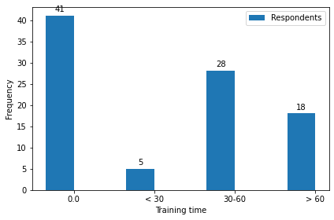

```python
labels = ['0.0','< 30', '30-60', '> 60']
temp_data = [41, 5, 28, 18]
#females = [22, 3, 23, 11]

x = np.arange(len(labels))  # the label locations
width = 0.35  # the width of the bars

fig, ax = plt.subplots()
rects1 = ax.bar(x - width/2, temp_data, width, label='Respondents')
#rects2 = ax.bar(x + width/2, females, width, label='Females')

# Add some text for labels, title and custom x-axis tick labels, etc.
ax.set_ylabel('Frequency')
ax.set_xlabel('Training time')
#ax.set_title('Number of responses by age groups and gender')
ax.set_xticks(x, labels)
ax.legend()

ax.bar_label(rects1, padding=3)
#ax.bar_label(rects2, padding=3)

fig.tight_layout()

plt.show()
```

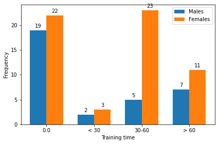

```python
labels = ['0.0','< 30', '30-60', '> 60']
males = [19, 2, 5, 7]
females = [22, 3, 23, 11]

x = np.arange(len(labels))  # the label locations
width = 0.35  # the width of the bars

fig, ax = plt.subplots()
rects1 = ax.bar(x - width/2, males, width, label='Males')
rects2 = ax.bar(x + width/2, females, width, label='Females')

# Add some text for labels, title and custom x-axis tick labels, etc.
ax.set_ylabel('Frequency')
ax.set_xlabel('Training time')
#ax.set_title('Number of responses by age groups and gender')
ax.set_xticks(x, labels)
ax.legend()

ax.bar_label(rects1, padding=3)
ax.bar_label(rects2, padding=3)

fig.tight_layout()

plt.show()
```

## 6.10 Moodle access period

```python
data['Moodle_Access'].value_counts(ascending=True)
```

```
ONCE/WEEK     8
Daily        84
Name: Moodle_Access, dtype: int64
```

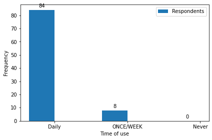

```python
labels = ['Daily','ONCE/WEEK', 'Never']
temp_data = [84, 8, 0]
#females = [52,4, 0]

x = np.arange(len(labels))  # the label locations
width = 0.35  # the width of the bars

fig, ax = plt.subplots()
rects1 = ax.bar(x - width/2, temp_data, width, label='Respondents')
#rects2 = ax.bar(x + width/2, females, width, label='Females')

# Add some text for labels, title and custom x-axis tick labels, etc.
ax.set_ylabel('Frequency')
ax.set_xlabel('Time of use')
#ax.set_title('Number of responses by moodle access and gender')
ax.set_xticks(x, labels)
ax.legend()

ax.bar_label(rects1, padding=3)
#ax.bar_label(rects2, padding=3)

fig.tight_layout()

plt.show()
```

[figure not shown]

```python
labels = ['Daily','ONCE/WEEK', 'Never']
males = [27, 4, 0]
females = [52,4, 0]

x = np.arange(len(labels))  # the label locations
width = 0.35  # the width of the bars

fig, ax = plt.subplots()
rects1 = ax.bar(x - width/2, males, width, label='Males')
rects2 = ax.bar(x + width/2, females, width, label='Females')

# Add some text for labels, title and custom x-axis tick labels, etc.
ax.set_ylabel('Frequency')
ax.set_xlabel('Time of use')
#ax.set_title('Number of responses by moodle access and gender')
ax.set_xticks(x, labels)
ax.legend()

ax.bar_label(rects1, padding=3)
ax.bar_label(rects2, padding=3)

fig.tight_layout()

plt.show()
```

## 6.11 Moodle for all course modules

```python
data['Moodle_For_All'].value_counts(ascending=True)
```

```
NO     22
YES    70
Name: Moodle_For_All, dtype: int64
```

[figure not shown]

```python
responses = ['YES', 'NO']
temp_data = [22, 70]

explode = (0.1, 0.0)
colors = ("grey", "beige")
wp = {'linewidth':1, 'edgecolor':"green"}

def func(pct, allval):
    absolute = int(pct/100.*np.sum(allval))
    return "{:.1f}%\n({:d})".format(pct, absolute)

fig, ax = plt.subplots(figsize = (10, 7))
wedges, texts, autotexts = ax.pie(temp_data,
                                  autopct = lambda pct: func(pct+1, temp_data),
                                  explode = explode,
                                  labels = responses,
                                  shadow = True,
                                  colors = colors,
                                  startangle = 90,
                                  wedgeprops = wp,
                                  textprops = dict(color = "black"))

ax.legend(wedges, responses,
          title = "Responses",
          loc = "center left",
          bbox_to_anchor = (1, 0.5))
ax.set_title("MOODLE FOR ALL PIE CHART")
plt.show()
```

#### The outputs above tell us about the frequencies and percentages of the respondents who used and did not use Moodle for all of their course modules.

## 6.12 Moodle experienced

```python
data['Moodle_experience'].value_counts(ascending=True)
```

```
YES    21
NO     71
Name: Moodle_experience, dtype: int64
```

[figure not shown]

```python
responses = ['YES', 'NO']
temp_data = [21, 71]

explode = (0.1, 0.0)
colors = ("grey", "beige")
wp = {'linewidth':1, 'edgecolor':"green"}

def func(pct, allval):
    absolute = int(pct/100.*np.sum(allval))
    return "{:.1f}%\n({:d})".format(pct, absolute)

fig, ax = plt.subplots(figsize = (10, 7))
wedges, texts, autotexts = ax.pie(temp_data,
                                  autopct = lambda pct: func(pct+1, temp_data),
                                  explode = explode,
                                  labels = responses,
                                  shadow = True,
                                  colors = colors,
                                  startangle = 90,
                                  wedgeprops = wp,
                                  textprops = dict(color = "black"))

ax.legend(wedges, responses,
          title = "Responses",
          loc = "center left",
          bbox_to_anchor = (1, 0.5))
ax.set_title("MOODLE EXPERIENCE PIE CHART")
plt.show()
```

#### The outputs above tell us about the frequencies and percentages of the respondents who had and had no Moodle experience before their registration with this institution.

# 7. Purpose of Moodle use

```python
print("Submitting assignments")
data['SUBMITTING'].value_counts()
```

```
Submitting assignments
```

```
YES    91
NO      1
Name: SUBMITTING, dtype: int64
```

```python
print("Interacting with other students")
data['INTERATING'].value_counts()
```

```
Interacting with other students
```

```
NO     65
YES    27
Name: INTERATING, dtype: int64
```

```python
print("Accessing course materials")
data['COURSE_MAT'].value_counts()
```

```
Accessing course materials
```

```
YES    88
NO      4
Name: COURSE_MAT, dtype: int64
```

```python
print("Participating in discussion forums")
data['DISCUSSIONS'].value_counts()
```

```
Participating in discussion forums
```

```
NO     47
YES    45
Name: DISCUSSIONS, dtype: int64
```

```python
print("Checking announcement from lecture or tutor")
data['ANNOUNCEMENTS'].value_counts()
```

```
Checking announcement from lecture or tutor
```

```
NO     71
YES    21
Name: ANNOUNCEMENTS, dtype: int64
```

#### The outputs above are telling us about the number of students who used and did not use some Moodle features.

# SUMMARY

```python
df = pd.DataFrame(dict(perception=['Submitting assignments',
                                   'Interacting with other students',
                                   'Accessing course materials',
                                   'Participating in discussion forums',
                                   'Checking announcement from lecture or tutor',
                                   'Other'],

                          YES = [91, 27, 88, 45, 71, 0],
                           NO = [1, 65, 4, 47, 21, 0]))

df
```

[output not shown]

[figure not shown]

```python
answers = {'YES': [91, 27, 88, 45, 71, 0],
           'NO': [1, 65, 4, 47, 21, 0]
          }
df = pd.DataFrame(answers, columns=['YES', 'NO'],
                           index = ['Submitting assignments',
                                   'Interacting with other students',
                                   'Accessing course materials',
                                   'Participating in discussion forums',
                                   'Checking announcement from lecture or tutor',
                                   'Other'])

plt.style.use('ggplot')
df.plot.barh()
plt.xlabel('Frequencies')
plt.show()
```

# 8. Respondents' perceptions of Moodle use

## CROSS TABULATION ALSO PERFORMED

## 8.1 Comfortable

```python
print("I feel comfortable using Moodle")
data['COMFORTABLE'].value_counts()
```

```
I feel comfortable using Moodle
```

```
STRONGLY_AGR     55
AGREE            27
NEUTRAL           7
STRONGLY_DISA     3
Name: COMFORTABLE, dtype: int64
```

```python
from scipy.stats import chi2_contingency
chi2_contingency(pd.crosstab(data.Gender, data.COMFORTABLE))
```

```
(12.088453888556613,
 0.007086216143407889,
 3,
 array([[17.31521739,  4.48913043, 35.27173913,  1.92391304],
        [ 9.68478261,  2.51086957, 19.72826087,  1.07608696]]))
```

```python
from scipy.stats import chi2_contingency
chi2_contingency(pd.crosstab(data.Age_Group, data.COMFORTABLE))
```

```
(22.841881372077452,
 0.0008512034171583511,
 6,
 array([[19.95652174,  5.17391304, 40.65217391,  2.2173913 ],
        [ 4.40217391,  1.14130435,  8.9673913 ,  0.48913043],
        [ 2.64130435,  0.68478261,  5.38043478,  0.29347826]]))
```

```python
from scipy.stats import chi2_contingency
chi2_contingency(pd.crosstab(data.Study_Level, data.COMFORTABLE))
```

```
(30.34261198043703,
 0.002479085121609671,
 12,
 array([[13.79347826,  3.57608696, 28.09782609,  1.5326087 ],
        [ 5.2826087 ,  1.36956522, 10.76086957,  0.58695652],
        [ 5.2826087 ,  1.36956522, 10.76086957,  0.58695652],
        [ 0.88043478,  0.22826087,  1.79347826,  0.09782609],
        [ 1.76086957,  0.45652174,  3.58695652,  0.19565217]]))
```

```python
from scipy.stats import chi2_contingency
chi2_contingency(pd.crosstab(data.School, data.COMFORTABLE))
```

```
(21.7344873294347,
 0.009759644230340299,
 9,
 array([[ 7.33695652,  1.90217391, 14.94565217,  0.81521739],
        [ 5.57608696,  1.44565217, 11.35869565,  0.61956522],
        [ 6.75      ,  1.75      , 13.75      ,  0.75      ],
        [ 7.33695652,  1.90217391, 14.94565217,  0.81521739]]))
```

```python
from scipy.stats import chi2_contingency
chi2_contingency(pd.crosstab(data.Location, data.COMFORTABLE))
```

```
(28.973406445406443,
 6.154598175645388e-05,
 6,
 array([[ 2.05434783,  0.5326087 ,  4.18478261,  0.22826087],
        [ 2.93478261,  0.76086957,  5.97826087,  0.32608696],
        [22.01086957,  5.70652174, 44.83695652,  2.44565217]]))
```

```python
from scipy.stats import chi2_contingency
chi2_contingency(pd.crosstab(data.Home_Computer, data.COMFORTABLE))
```

```
(7.533025493025493,
 0.0567159302556184,
 3,
 array([[11.73913043,  3.04347826, 23.91304348,  1.30434783],
        [15.26086957,  3.95652174, 31.08695652,  1.69565217]]))
```

```python
from scipy.stats import chi2_contingency
chi2_contingency(pd.crosstab(data.Home_Internet, data.COMFORTABLE))
```

```
(2.0305916305916307,
 0.5660816370762929,
 3,
 array([[ 6.75,  1.75, 13.75,  0.75],
        [20.25,  5.25, 41.25,  2.25]]))
```

```python
from scipy.stats import chi2_contingency
chi2_contingency(pd.crosstab(data.Moodle_Training, data.COMFORTABLE))
```

```
(4.475881586928932,
 0.2144517101262682,
 3,
 array([[12.0326087 ,  3.11956522, 24.51086957,  1.33695652],
        [14.9673913 ,  3.88043478, 30.48913043,  1.66304348]]))
```

```python
from scipy.stats import chi2_contingency
chi2_contingency(pd.crosstab(data.Training_Time, data.COMFORTABLE))
```

```
(11.645136682906717,
 0.23406192333693085,
 9,
 array([[12.0326087 ,  3.11956522, 24.51086957,  1.33695652],
        [ 8.2173913 ,  2.13043478, 16.73913043,  0.91304348],
        [ 1.4673913 ,  0.38043478,  2.98913043,  0.16304348],
        [ 5.2826087 ,  1.36956522, 10.76086957,  0.58695652]]))
```

```python
from scipy.stats import chi2_contingency
chi2_contingency(pd.crosstab(data.Moodle_Access, data.COMFORTABLE))
```

```
(2.5622987242034854,
 0.4641374349825096,
 3,
 array([[24.65217391,  6.39130435, 50.2173913 ,  2.73913043],
        [ 2.34782609,  0.60869565,  4.7826087 ,  0.26086957]]))
```

```python
from scipy.stats import chi2_contingency
chi2_contingency(pd.crosstab(data.Moodle_For_All, data.COMFORTABLE))
```

```
(11.790192837465563,
 0.00813754234519789,
 3,
 array([[ 6.45652174,  1.67391304, 13.15217391,  0.7173913 ],
        [20.54347826,  5.32608696, 41.84782609,  2.2826087 ]]))
```

```python
from scipy.stats import chi2_contingency
chi2_contingency(pd.crosstab(data.Moodle_experience, data.COMFORTABLE))
```

```
(1.3449356714279586,
 0.7184913100420232,
 3,
 array([[20.83695652,  5.40217391, 42.44565217,  2.31521739],
        [ 6.16304348,  1.59782609, 12.55434783,  0.68478261]]))
```

#### The outputs above are showing us the number of respondents who are not comfortable with using Moodle. We also run chi-square test to check if each demographic is related/associated with perceptions.

## 8.2 Support

```python
print("I feel in need of technical support to use Moodle")
data['SUPPORT'].value_counts()
```

```
I feel in need of technical support to use Moodle
```

```
NEUTRAL          38
STRONGLY_DISA    29
DISAGREE         14
AGREE             7
STRONGLY_AGR      4
Name: SUPPORT, dtype: int64
```

```python
from scipy.stats import chi2_contingency
chi2_contingency(pd.crosstab(data.Gender, data.SUPPORT))
```

```
(10.003080066139526,
 0.04037583063700907,
 4,
 array([[ 4.48913043,  8.97826087, 24.36956522,  2.56521739, 18.59782609],
        [ 2.51086957,  5.02173913, 13.63043478,  1.43478261, 10.40217391]]))
```

```python
from scipy.stats import chi2_contingency
chi2_contingency(pd.crosstab(data.Age_Group, data.SUPPORT))
```

```
(23.33371613618224,
 0.0029612014126115093,
 8,
 array([[ 5.17391304, 10.34782609, 28.08695652,  2.95652174, 21.43478261],
        [ 1.14130435,  2.2826087 ,  6.19565217,  0.65217391,  4.72826087],
        [ 0.68478261,  1.36956522,  3.7173913 ,  0.39130435,  2.83695652]]))
```

```python
from scipy.stats import chi2_contingency
chi2_contingency(pd.crosstab(data.Study_Level, data.SUPPORT))
```

```
(50.85428538330419,
 1.6742460310450377e-05,
 16,
 array([[ 3.57608696,  7.15217391, 19.41304348,  2.04347826, 14.81521739],
        [ 1.36956522,  2.73913043,  7.43478261,  0.7826087 ,  5.67391304],
        [ 1.36956522,  2.73913043,  7.43478261,  0.7826087 ,  5.67391304],
        [ 0.22826087,  0.45652174,  1.23913043,  0.13043478,  0.94565217],
        [ 0.45652174,  0.91304348,  2.47826087,  0.26086957,  1.89130435]]))
```

```python
from scipy.stats import chi2_contingency
chi2_contingency(pd.crosstab(data.School, data.SUPPORT))
```

```
(28.152297258572933,
 0.005255099837949519,
 12,
 array([[ 1.90217391,  3.80434783, 10.32608696,  1.08695652,  7.88043478],
        [ 1.44565217,  2.89130435,  7.84782609,  0.82608696,  5.98913043],
        [ 1.75      ,  3.5       ,  9.5       ,  1.        ,  7.25      ],
        [ 1.90217391,  3.80434783, 10.32608696,  1.08695652,  7.88043478]]))
```

```python
from scipy.stats import chi2_contingency
chi2_contingency(pd.crosstab(data.Location, data.SUPPORT))
```

```
(13.3835539587886,
 0.09931649663926365,
 8,
 array([[ 0.5326087 ,  1.06521739,  2.89130435,  0.30434783,  2.20652174],
        [ 0.76086957,  1.52173913,  4.13043478,  0.43478261,  3.15217391],
        [ 5.70652174, 11.41304348, 30.97826087,  3.26086957, 23.64130435]]))
```

```python
from scipy.stats import chi2_contingency
chi2_contingency(pd.crosstab(data.Home_Computer, data.SUPPORT))
```

```
(13.768853832193212,
 0.008070519870896735,
 4,
 array([[ 3.04347826,  6.08695652, 16.52173913,  1.73913043, 12.60869565],
        [ 3.95652174,  7.91304348, 21.47826087,  2.26086957, 16.39130435]]))
```

```python
from scipy.stats import chi2_contingency
chi2_contingency(pd.crosstab(data.Home_Internet, data.SUPPORT))
```

```
(6.3925330567798815,
 0.1716888726279614,
 4,
 array([[ 1.75,  3.5 ,  9.5 ,  1.  ,  7.25],
        [ 5.25, 10.5 , 28.5 ,  3.  , 21.75]]))
```

```python
from scipy.stats import chi2_contingency
chi2_contingency(pd.crosstab(data.Moodle_Training, data.SUPPORT))
```

```
(4.704954887094052,
 0.3189318499170775,
 4,
 array([[ 3.11956522,  6.23913043, 16.93478261,  1.7826087 , 12.92391304],
        [ 3.88043478,  7.76086957, 21.06521739,  2.2173913 , 16.07608696]]))
```

```python
from scipy.stats import chi2_contingency
chi2_contingency(pd.crosstab(data.Training_Time, data.SUPPORT))
```

```
(23.60142056350376,
 0.02303294172871827,
 12,
 array([[ 3.11956522,  6.23913043, 16.93478261,  1.7826087 , 12.92391304],
        [ 2.13043478,  4.26086957, 11.56521739,  1.2173913 ,  8.82608696],
        [ 0.38043478,  0.76086957,  2.06521739,  0.2173913 ,  1.57608696],
        [ 1.36956522,  2.73913043,  7.43478261,  0.7826087 ,  5.67391304]]))
```

```python
from scipy.stats import chi2_contingency
chi2_contingency(pd.crosstab(data.Moodle_Access, data.SUPPORT))
```

```
(4.055390940405199,
 0.39856140154505537,
 4,
 array([[ 6.39130435, 12.7826087 , 34.69565217,  3.65217391, 26.47826087],
        [ 0.60869565,  1.2173913 ,  3.30434783,  0.34782609,  2.52173913]]))
```

```python
from scipy.stats import chi2_contingency
chi2_contingency(pd.crosstab(data.Moodle_For_All, data.SUPPORT))
```

```
(2.470647734427874,
 0.6498993705502296,
 4,
 array([[ 1.67391304,  3.34782609,  9.08695652,  0.95652174,  6.93478261],
        [ 5.32608696, 10.65217391, 28.91304348,  3.04347826, 22.06521739]]))
```

```python
from scipy.stats import chi2_contingency
chi2_contingency(pd.crosstab(data.Moodle_experience, data.SUPPORT))
```

```
(7.878617657026768,
 0.09612715618460199,
 4,
 array([[ 5.40217391, 10.80434783, 29.32608696,  3.08695652, 22.38043478],
        [ 1.59782609,  3.19565217,  8.67391304,  0.91304348,  6.61956522]]))
```

## 8.3 Easy to use

```python
print("I feel that Moodle is easy to use")
data['EASY_TO_USE'].value_counts()
```

```
I feel that Moodle is easy to use
```

```
STRONGLY_AGR    59
AGREE           22
NEUTRAL         11
Name: EASY_TO_USE, dtype: int64
```

```python
from scipy.stats import chi2_contingency
chi2_contingency(pd.crosstab(data.Gender, data.EASY_TO_USE))
```

```
(1.2245523317054485,
 0.5421155188446243,
 2,
 array([[14.10869565,  7.05434783, 37.83695652],
        [ 7.89130435,  3.94565217, 21.16304348]]))
```

```python
from scipy.stats import chi2_contingency
chi2_contingency(pd.crosstab(data.Age_Group, data.EASY_TO_USE))
```

```
(1.1670594277772743,
 0.8834917170898514,
 4,
 array([[16.26086957,  8.13043478, 43.60869565],
        [ 3.58695652,  1.79347826,  9.61956522],
        [ 2.15217391,  1.07608696,  5.77173913]]))
```

```python
from scipy.stats import chi2_contingency
chi2_contingency(pd.crosstab(data.Study_Level, data.EASY_TO_USE))
```

```
(12.325865943969083,
 0.13724599541607233,
 8,
 array([[11.23913043,  5.61956522, 30.14130435],
        [ 4.30434783,  2.15217391, 11.54347826],
        [ 4.30434783,  2.15217391, 11.54347826],
        [ 0.7173913 ,  0.35869565,  1.92391304],
        [ 1.43478261,  0.7173913 ,  3.84782609]]))
```

```python
from scipy.stats import chi2_contingency
chi2_contingency(pd.crosstab(data.School, data.EASY_TO_USE))
```

```
(11.820381153191146,
 0.06609795256485222,
 6,
 array([[ 5.97826087,  2.98913043, 16.0326087 ],
        [ 4.54347826,  2.27173913, 12.18478261],
        [ 5.5       ,  2.75      , 14.75      ],
        [ 5.97826087,  2.98913043, 16.0326087 ]]))
```

```python
from scipy.stats import chi2_contingency
chi2_contingency(pd.crosstab(data.Location, data.EASY_TO_USE))
```

```
(25.615745836084827,
 3.782145638124154e-05,
 4,
 array([[ 1.67391304,  0.83695652,  4.48913043],
        [ 2.39130435,  1.19565217,  6.41304348],
        [17.93478261,  8.9673913 , 48.09782609]]))
```

```python
from scipy.stats import chi2_contingency
chi2_contingency(pd.crosstab(data.Home_Computer, data.EASY_TO_USE))
```

```
(0.5865177195685667,
 0.745829050559524,
 2,
 array([[ 9.56521739,  4.7826087 , 25.65217391],
        [12.43478261,  6.2173913 , 33.34782609]]))
```

```python
from scipy.stats import chi2_contingency
chi2_contingency(pd.crosstab(data.Home_Internet, data.EASY_TO_USE))
```

```
(3.198767334360555,
 0.20202099179958846,
 2,
 array([[ 5.5 ,  2.75, 14.75],
        [16.5 ,  8.25, 44.25]]))
```

```python
from scipy.stats import chi2_contingency
chi2_contingency(pd.crosstab(data.Moodle_Training, data.EASY_TO_USE))
```

```
(7.741019366143992,
 0.020847740976209606,
 2,
 array([[ 9.80434783,  4.90217391, 26.29347826],
        [12.19565217,  6.09782609, 32.70652174]]))
```

```python
from scipy.stats import chi2_contingency
chi2_contingency(pd.crosstab(data.Training_Time, data.EASY_TO_USE))
```

```
(14.930958495365275,
 0.020800553371743497,
 6,
 array([[ 9.80434783,  4.90217391, 26.29347826],
        [ 6.69565217,  3.34782609, 17.95652174],
        [ 1.19565217,  0.59782609,  3.20652174],
        [ 4.30434783,  2.15217391, 11.54347826]]))
```

```python
from scipy.stats import chi2_contingency
chi2_contingency(pd.crosstab(data.Moodle_Access, data.EASY_TO_USE))
```

```
(0.6408577298407809,
 0.7258376839936937,
 2,
 array([[20.08695652, 10.04347826, 53.86956522],
        [ 1.91304348,  0.95652174,  5.13043478]]))
```

```python
from scipy.stats import chi2_contingency
chi2_contingency(pd.crosstab(data.Moodle_For_All, data.EASY_TO_USE))
```

```
(8.330498469173353,
 0.01552584484032758,
 2,
 array([[ 5.26086957,  2.63043478, 14.10869565],
        [16.73913043,  8.36956522, 44.89130435]]))
```

```python
from scipy.stats import chi2_contingency
chi2_contingency(pd.crosstab(data.Moodle_experience, data.EASY_TO_USE))
```

```
(3.6914698256307226,
 0.15790922872021101,
 2,
 array([[16.97826087,  8.48913043, 45.5326087 ],
        [ 5.02173913,  2.51086957, 13.4673913 ]]))
```

## 8.4 Difficult to use

```python
print("I feel that Moodle is difficult to use")
data['DIFFICULT_TO_USE'].value_counts()
```

```
I feel that Moodle is difficult to use
```

```
STRONGLY_DISA    71
DISAGREE         17
AGREE             3
NEUTRAL           1
Name: DIFFICULT_TO_USE, dtype: int64
```

```python
from scipy.stats import chi2_contingency
chi2_contingency(pd.crosstab(data.Gender, data.DIFFICULT_TO_USE))
```

```
(6.057244399962725,
 0.1088581332175817,
 3,
 array([[ 1.92391304, 10.90217391,  0.64130435, 45.5326087 ],
        [ 1.07608696,  6.09782609,  0.35869565, 25.4673913 ]]))
```

```python
from scipy.stats import chi2_contingency
chi2_contingency(pd.crosstab(data.Age_Group, data.DIFFICULT_TO_USE))
```

```
(18.784697109995616,
 0.004543127994463303,
 6,
 array([[ 2.2173913 , 12.56521739,  0.73913043, 52.47826087],
        [ 0.48913043,  2.77173913,  0.16304348, 11.57608696],
        [ 0.29347826,  1.66304348,  0.09782609,  6.94565217]]))
```

```python
from scipy.stats import chi2_contingency
chi2_contingency(pd.crosstab(data.Study_Level, data.DIFFICULT_TO_USE))
```

```
(30.070585101486408,
 0.002724908191089667,
 12,
 array([[1.53260870e+00, 8.68478261e+00, 5.10869565e-01, 3.62717391e+01],
        [5.86956522e-01, 3.32608696e+00, 1.95652174e-01, 1.38913043e+01],
        [5.86956522e-01, 3.32608696e+00, 1.95652174e-01, 1.38913043e+01],
        [9.78260870e-02, 5.54347826e-01, 3.26086957e-02, 2.31521739e+00],
        [1.95652174e-01, 1.10869565e+00, 6.52173913e-02, 4.63043478e+00]]))
```

```python
from scipy.stats import chi2_contingency
chi2_contingency(pd.crosstab(data.School, data.DIFFICULT_TO_USE))
```

```
(19.206914053983343,
 0.023489913449145715,
 9,
 array([[ 0.81521739,  4.61956522,  0.27173913, 19.29347826],
        [ 0.61956522,  3.51086957,  0.20652174, 14.66304348],
        [ 0.75      ,  4.25      ,  0.25      , 17.75      ],
        [ 0.81521739,  4.61956522,  0.27173913, 19.29347826]]))
```

```python
from scipy.stats import chi2_contingency
chi2_contingency(pd.crosstab(data.Location, data.DIFFICULT_TO_USE))
```

```
(25.84623979169132,
 0.00023781433952120874,
 6,
 array([[ 0.22826087,  1.29347826,  0.07608696,  5.40217391],
        [ 0.32608696,  1.84782609,  0.10869565,  7.7173913 ],
        [ 2.44565217, 13.85869565,  0.81521739, 57.88043478]]))
```

```python
from scipy.stats import chi2_contingency
chi2_contingency(pd.crosstab(data.Home_Computer, data.DIFFICULT_TO_USE))
```

```
(4.101918297112995,
 0.25066702108415134,
 3,
 array([[ 1.30434783,  7.39130435,  0.43478261, 30.86956522],
        [ 1.69565217,  9.60869565,  0.56521739, 40.13043478]]))
```

```python
from scipy.stats import chi2_contingency
chi2_contingency(pd.crosstab(data.Home_Internet, data.DIFFICULT_TO_USE))
```

```
(4.218724109362054,
 0.23879392009017666,
 3,
 array([[ 0.75,  4.25,  0.25, 17.75],
        [ 2.25, 12.75,  0.75, 53.25]]))
```

```python
from scipy.stats import chi2_contingency
chi2_contingency(pd.crosstab(data.Moodle_Training, data.DIFFICULT_TO_USE))
```

```
(6.5630783604487934,
 0.08720776915933469,
 3,
 array([[ 1.33695652,  7.57608696,  0.44565217, 31.64130435],
        [ 1.66304348,  9.42391304,  0.55434783, 39.35869565]]))
```

```python
from scipy.stats import chi2_contingency
chi2_contingency(pd.crosstab(data.Training_Time, data.DIFFICULT_TO_USE))
```

```
(8.36960471581281,
 0.4973703021126137,
 9,
 array([[ 1.33695652,  7.57608696,  0.44565217, 31.64130435],
        [ 0.91304348,  5.17391304,  0.30434783, 21.60869565],
        [ 0.16304348,  0.92391304,  0.05434783,  3.85869565],
        [ 0.58695652,  3.32608696,  0.19565217, 13.89130435]]))
```

```python
from scipy.stats import chi2_contingency
chi2_contingency(pd.crosstab(data.Moodle_Access, data.DIFFICULT_TO_USE))
```

```
(10.960547599321417,
 0.011941133739460933,
 3,
 array([[ 2.73913043, 15.52173913,  0.91304348, 64.82608696],
        [ 0.26086957,  1.47826087,  0.08695652,  6.17391304]]))
```

```python
from scipy.stats import chi2_contingency
chi2_contingency(pd.crosstab(data.Moodle_For_All, data.DIFFICULT_TO_USE))
```

```
(11.238692045320047,
 0.010502776607948426,
 3,
 array([[ 0.7173913 ,  4.06521739,  0.23913043, 16.97826087],
        [ 2.2826087 , 12.93478261,  0.76086957, 54.02173913]]))
```

```python
from scipy.stats import chi2_contingency
chi2_contingency(pd.crosstab(data.Moodle_experience, data.DIFFICULT_TO_USE))
```

```
(1.6991226564023747,
 0.637128866846745,
 3,
 array([[ 2.31521739, 13.11956522,  0.77173913, 54.79347826],
        [ 0.68478261,  3.88043478,  0.22826087, 16.20652174]]))
```

## 8.5 User friendly

```python
print("I feel that Moodle is user friendly")
data['USER_FRIENDLY'].value_counts()
```

```
I feel that Moodle is user friendly
```

```
STRONGLY_AGR     43
AGREE            27
NEUTRAL          21
STRONGLY_DISA     1
Name: USER_FRIENDLY, dtype: int64
```

```python
from scipy.stats import chi2_contingency
chi2_contingency(pd.crosstab(data.Gender, data.USER_FRIENDLY))
```

```
(2.7055959170004633,
 0.4392771643860818,
 3,
 array([[17.31521739, 13.4673913 , 27.57608696,  0.64130435],
        [ 9.68478261,  7.5326087 , 15.42391304,  0.35869565]]))
```

```python
from scipy.stats import chi2_contingency
chi2_contingency(pd.crosstab(data.Age_Group, data.USER_FRIENDLY))
```

```
(0.5660367161507154,
 0.9969396569956178,
 6,
 array([[19.95652174, 15.52173913, 31.7826087 ,  0.73913043],
        [ 4.40217391,  3.42391304,  7.01086957,  0.16304348],
        [ 2.64130435,  2.05434783,  4.20652174,  0.09782609]]))
```

```python
from scipy.stats import chi2_contingency
chi2_contingency(pd.crosstab(data.Study_Level, data.USER_FRIENDLY))
```

```
(14.565600873369304,
 0.2660558906815321,
 12,
 array([[13.79347826, 10.72826087, 21.9673913 ,  0.51086957],
        [ 5.2826087 ,  4.10869565,  8.41304348,  0.19565217],
        [ 5.2826087 ,  4.10869565,  8.41304348,  0.19565217],
        [ 0.88043478,  0.68478261,  1.40217391,  0.0326087 ],
        [ 1.76086957,  1.36956522,  2.80434783,  0.06521739]]))
```

```python
from scipy.stats import chi2_contingency
chi2_contingency(pd.crosstab(data.School, data.USER_FRIENDLY))
```

```
(10.76910052910053,
 0.29186860989782515,
 9,
 array([[ 7.33695652,  5.70652174, 11.68478261,  0.27173913],
        [ 5.57608696,  4.33695652,  8.88043478,  0.20652174],
        [ 6.75      ,  5.25      , 10.75      ,  0.25      ],
        [ 7.33695652,  5.70652174, 11.68478261,  0.27173913]]))
```

```python
from scipy.stats import chi2_contingency
chi2_contingency(pd.crosstab(data.Location, data.USER_FRIENDLY))
```

```
(13.108141585660967,
 0.04135043358226491,
 6,
 array([[ 2.05434783,  1.59782609,  3.27173913,  0.07608696],
        [ 2.93478261,  2.2826087 ,  4.67391304,  0.10869565],
        [22.01086957, 17.11956522, 35.05434783,  0.81521739]]))
```

```python
from scipy.stats import chi2_contingency
chi2_contingency(pd.crosstab(data.Home_Computer, data.USER_FRIENDLY))
```

```
(2.675202317062782,
 0.4444578628336959,
 3,
 array([[11.73913043,  9.13043478, 18.69565217,  0.43478261],
        [15.26086957, 11.86956522, 24.30434783,  0.56521739]]))
```

```python
from scipy.stats import chi2_contingency
chi2_contingency(pd.crosstab(data.Home_Internet, data.USER_FRIENDLY))
```

```
(1.5820515975554734,
 0.6634663123540578,
 3,
 array([[ 6.75,  5.25, 10.75,  0.25],
        [20.25, 15.75, 32.25,  0.75]]))
```

```python
from scipy.stats import chi2_contingency
chi2_contingency(pd.crosstab(data.Moodle_Training, data.USER_FRIENDLY))
```

```
(1.150831223857372,
 0.7648195189039116,
 3,
 array([[12.0326087 ,  9.35869565, 19.16304348,  0.44565217],
        [14.9673913 , 11.64130435, 23.83695652,  0.55434783]]))
```

```python
from scipy.stats import chi2_contingency
chi2_contingency(pd.crosstab(data.Training_Time, data.USER_FRIENDLY))
```

```
(19.39682453935756,
 0.022022407111278116,
 9,
 array([[12.0326087 ,  9.35869565, 19.16304348,  0.44565217],
        [ 8.2173913 ,  6.39130435, 13.08695652,  0.30434783],
        [ 1.4673913 ,  1.14130435,  2.33695652,  0.05434783],
        [ 5.2826087 ,  4.10869565,  8.41304348,  0.19565217]]))
```

```python
from scipy.stats import chi2_contingency
chi2_contingency(pd.crosstab(data.Moodle_Access, data.USER_FRIENDLY))
```

```
(2.006117175552392,
 0.5711380330743245,
 3,
 array([[24.65217391, 19.17391304, 39.26086957,  0.91304348],
        [ 2.34782609,  1.82608696,  3.73913043,  0.08695652]]))
```

```python
from scipy.stats import chi2_contingency
chi2_contingency(pd.crosstab(data.Moodle_For_All, data.USER_FRIENDLY))
```

```
(5.87611281298989,
 0.11779565839296025,
 3,
 array([[ 6.45652174,  5.02173913, 10.2826087 ,  0.23913043],
        [20.54347826, 15.97826087, 32.7173913 ,  0.76086957]]))
```

```python
from scipy.stats import chi2_contingency
chi2_contingency(pd.crosstab(data.Moodle_experience, data.USER_FRIENDLY))
```

```
(6.204377076618275,
 0.10207933204506013,
 3,
 array([[20.83695652, 16.20652174, 33.18478261,  0.77173913],
        [ 6.16304348,  4.79347826,  9.81521739,  0.22826087]]))
```

## 8.6 Error messages are helpful

```python
print("I feel that error messages on Moodle are helpful")
data['HELPFUL_ERR_MSG'].value_counts()
```

```
I feel that error messages on Moodle are helpful
```

```
NEUTRAL          39
STRONGLY_AGR     19
AGREE            18
DISAGREE         13
STRONGLY_DISA     3
Name: HELPFUL_ERR_MSG, dtype: int64
```

```python
from scipy.stats import chi2_contingency
chi2_contingency(pd.crosstab(data.Gender, data.HELPFUL_ERR_MSG))
```

```
(12.850829482408432,
 0.012028142089788469,
 4,
 array([[11.54347826,  8.33695652, 25.01086957, 12.18478261,  1.92391304],
        [ 6.45652174,  4.66304348, 13.98913043,  6.81521739,  1.07608696]]))
```

```python
from scipy.stats import chi2_contingency
chi2_contingency(pd.crosstab(data.Age_Group, data.HELPFUL_ERR_MSG))
```

```
(17.570727598281778,
 0.024685415288919148,
 8,
 array([[13.30434783,  9.60869565, 28.82608696, 14.04347826,  2.2173913 ],
        [ 2.93478261,  2.11956522,  6.35869565,  3.09782609,  0.48913043],
        [ 1.76086957,  1.27173913,  3.81521739,  1.85869565,  0.29347826]]))
```

```python
from scipy.stats import chi2_contingency
chi2_contingency(pd.crosstab(data.Study_Level, data.HELPFUL_ERR_MSG))
```

```
(33.30078621418674,
 0.006740633347464708,
 16,
 array([[ 9.19565217,  6.64130435, 19.92391304,  9.70652174,  1.5326087 ],
        [ 3.52173913,  2.54347826,  7.63043478,  3.7173913 ,  0.58695652],
        [ 3.52173913,  2.54347826,  7.63043478,  3.7173913 ,  0.58695652],
        [ 0.58695652,  0.42391304,  1.27173913,  0.61956522,  0.09782609],
        [ 1.17391304,  0.84782609,  2.54347826,  1.23913043,  0.19565217]]))
```

```python
from scipy.stats import chi2_contingency
chi2_contingency(pd.crosstab(data.School, data.HELPFUL_ERR_MSG))
```

```
(34.08944006439852,
 0.0006529778990722018,
 12,
 array([[ 4.89130435,  3.5326087 , 10.59782609,  5.16304348,  0.81521739],
        [ 3.7173913 ,  2.68478261,  8.05434783,  3.92391304,  0.61956522],
        [ 4.5       ,  3.25      ,  9.75      ,  4.75      ,  0.75      ],
        [ 4.89130435,  3.5326087 , 10.59782609,  5.16304348,  0.81521739]]))
```

```python
from scipy.stats import chi2_contingency
chi2_contingency(pd.crosstab(data.Location, data.HELPFUL_ERR_MSG))
```

```
(24.818223336118074,
 0.0016687089133649454,
 8,
 array([[ 1.36956522,  0.98913043,  2.9673913 ,  1.44565217,  0.22826087],
        [ 1.95652174,  1.41304348,  4.23913043,  2.06521739,  0.32608696],
        [14.67391304, 10.59782609, 31.79347826, 15.48913043,  2.44565217]]))
```

```python
from scipy.stats import chi2_contingency
chi2_contingency(pd.crosstab(data.Home_Computer, data.HELPFUL_ERR_MSG))
```

```
(13.6686805771826,
 0.008431137200048391,
 4,
 array([[ 7.82608696,  5.65217391, 16.95652174,  8.26086957,  1.30434783],
        [10.17391304,  7.34782609, 22.04347826, 10.73913043,  1.69565217]]))
```

```python
from scipy.stats import chi2_contingency
chi2_contingency(pd.crosstab(data.Home_Internet, data.HELPFUL_ERR_MSG))
```

```
(4.209926525715999,
 0.378340241227519,
 4,
 array([[ 4.5 ,  3.25,  9.75,  4.75,  0.75],
        [13.5 ,  9.75, 29.25, 14.25,  2.25]]))
```

```python
from scipy.stats import chi2_contingency
chi2_contingency(pd.crosstab(data.Moodle_Training, data.HELPFUL_ERR_MSG))
```

```
(15.447326577735096,
 0.003857931819203113,
 4,
 array([[ 8.02173913,  5.79347826, 17.38043478,  8.4673913 ,  1.33695652],
        [ 9.97826087,  7.20652174, 21.61956522, 10.5326087 ,  1.66304348]]))
```

```python
from scipy.stats import chi2_contingency
chi2_contingency(pd.crosstab(data.Training_Time, data.HELPFUL_ERR_MSG))
```

```
(22.06228722386189,
 0.03682762393935449,
 12,
 array([[ 8.02173913,  5.79347826, 17.38043478,  8.4673913 ,  1.33695652],
        [ 5.47826087,  3.95652174, 11.86956522,  5.7826087 ,  0.91304348],
        [ 0.97826087,  0.70652174,  2.11956522,  1.0326087 ,  0.16304348],
        [ 3.52173913,  2.54347826,  7.63043478,  3.7173913 ,  0.58695652]]))
```

```python
from scipy.stats import chi2_contingency
chi2_contingency(pd.crosstab(data.Moodle_Access, data.HELPFUL_ERR_MSG))
```

```
(17.901698691172374,
 0.0012898988988126726,
 4,
 array([[16.43478261, 11.86956522, 35.60869565, 17.34782609,  2.73913043],
        [ 1.56521739,  1.13043478,  3.39130435,  1.65217391,  0.26086957]]))
```

```python
from scipy.stats import chi2_contingency
chi2_contingency(pd.crosstab(data.Moodle_For_All, data.HELPFUL_ERR_MSG))
```

```
(9.804443509706667,
 0.04385384379448819,
 4,
 array([[ 4.30434783,  3.10869565,  9.32608696,  4.54347826,  0.7173913 ],
        [13.69565217,  9.89130435, 29.67391304, 14.45652174,  2.2826087 ]]))
```

```python
from scipy.stats import chi2_contingency
chi2_contingency(pd.crosstab(data.Moodle_experience, data.HELPFUL_ERR_MSG))
```

```
(8.160385313832313,
 0.08587663653414045,
 4,
 array([[13.89130435, 10.0326087 , 30.09782609, 14.66304348,  2.31521739],
        [ 4.10869565,  2.9673913 ,  8.90217391,  4.33695652,  0.68478261]]))
```

## 8.7 Error messeges are confusing

```python
print("I feel that error messages on Moodle are confusing")
data['CONFUSING_ERR_MSG'].value_counts()
```

```
I feel that error messages on Moodle are confusing
```

```
NEUTRAL          37
STRONGLY_DISA    26
DISAGREE         17
AGREE             9
STRONGLY_AGR      3
Name: CONFUSING_ERR_MSG, dtype: int64
```

```python
from scipy.stats import chi2_contingency
chi2_contingency(pd.crosstab(data.Gender, data.CONFUSING_ERR_MSG))
```

```
(3.665337691259925,
 0.45318741320165923,
 4,
 array([[ 5.77173913, 10.90217391, 23.72826087,  1.92391304, 16.67391304],
        [ 3.22826087,  6.09782609, 13.27173913,  1.07608696,  9.32608696]]))
```

```python
from scipy.stats import chi2_contingency
chi2_contingency(pd.crosstab(data.Age_Group, data.CONFUSING_ERR_MSG))
```

```
(9.48148816903142,
 0.3033183981485986,
 8,
 array([[ 6.65217391, 12.56521739, 27.34782609,  2.2173913 , 19.2173913 ],
        [ 1.4673913 ,  2.77173913,  6.0326087 ,  0.48913043,  4.23913043],
        [ 0.88043478,  1.66304348,  3.61956522,  0.29347826,  2.54347826]]))
```

```python
from scipy.stats import chi2_contingency
chi2_contingency(pd.crosstab(data.Study_Level, data.CONFUSING_ERR_MSG))
```

```
(40.38295646180502,
 0.0006843537541731871,
 16,
 array([[ 4.59782609,  8.68478261, 18.90217391,  1.5326087 , 13.2826087 ],
        [ 1.76086957,  3.32608696,  7.23913043,  0.58695652,  5.08695652],
        [ 1.76086957,  3.32608696,  7.23913043,  0.58695652,  5.08695652],
        [ 0.29347826,  0.55434783,  1.20652174,  0.09782609,  0.84782609],
        [ 0.58695652,  1.10869565,  2.41304348,  0.19565217,  1.69565217]]))
```

```python
from scipy.stats import chi2_contingency
chi2_contingency(pd.crosstab(data.School, data.CONFUSING_ERR_MSG))
```

```
(31.84515472366865,
 0.0014619794711962235,
 12,
 array([[ 2.44565217,  4.61956522, 10.05434783,  0.81521739,  7.06521739],
        [ 1.85869565,  3.51086957,  7.64130435,  0.61956522,  5.36956522],
        [ 2.25      ,  4.25      ,  9.25      ,  0.75      ,  6.5       ],
        [ 2.44565217,  4.61956522, 10.05434783,  0.81521739,  7.06521739]]))
```

```python
from scipy.stats import chi2_contingency
chi2_contingency(pd.crosstab(data.Location, data.CONFUSING_ERR_MSG))
```

```
(14.782053520877048,
 0.06352443167884407,
 8,
 array([[ 0.68478261,  1.29347826,  2.81521739,  0.22826087,  1.97826087],
        [ 0.97826087,  1.84782609,  4.02173913,  0.32608696,  2.82608696],
        [ 7.33695652, 13.85869565, 30.16304348,  2.44565217, 21.19565217]]))
```

```python
from scipy.stats import chi2_contingency
chi2_contingency(pd.crosstab(data.Home_Computer, data.CONFUSING_ERR_MSG))
```

```
(8.752981523117267,
 0.06757921085159661,
 4,
 array([[ 3.91304348,  7.39130435, 16.08695652,  1.30434783, 11.30434783],
        [ 5.08695652,  9.60869565, 20.91304348,  1.69565217, 14.69565217]]))
```

```python
from scipy.stats import chi2_contingency
chi2_contingency(pd.crosstab(data.Home_Internet, data.CONFUSING_ERR_MSG))
```

```
(11.568582156817452,
 0.02086501858454921,
 4,
 array([[ 2.25,  4.25,  9.25,  0.75,  6.5 ],
        [ 6.75, 12.75, 27.75,  2.25, 19.5 ]]))
```

```python
from scipy.stats import chi2_contingency
chi2_contingency(pd.crosstab(data.Moodle_Training, data.CONFUSING_ERR_MSG))
```

```
(6.415223366864855,
 0.1702109901747034,
 4,
 array([[ 4.01086957,  7.57608696, 16.48913043,  1.33695652, 11.58695652],
        [ 4.98913043,  9.42391304, 20.51086957,  1.66304348, 14.41304348]]))
```

```python
from scipy.stats import chi2_contingency
chi2_contingency(pd.crosstab(data.Training_Time, data.CONFUSING_ERR_MSG))
```

```
(19.65869526696882,
 0.07382406766906596,
 12,
 array([[ 4.01086957,  7.57608696, 16.48913043,  1.33695652, 11.58695652],
        [ 2.73913043,  5.17391304, 11.26086957,  0.91304348,  7.91304348],
        [ 0.48913043,  0.92391304,  2.01086957,  0.16304348,  1.41304348],
        [ 1.76086957,  3.32608696,  7.23913043,  0.58695652,  5.08695652]]))
```

```python
from scipy.stats import chi2_contingency
chi2_contingency(pd.crosstab(data.Moodle_Access, data.CONFUSING_ERR_MSG))
```

```
(14.120394311570784,
 0.0069205561883008485,
 4,
 array([[ 8.2173913 , 15.52173913, 33.7826087 ,  2.73913043, 23.73913043],
        [ 0.7826087 ,  1.47826087,  3.2173913 ,  0.26086957,  2.26086957]]))
```

```python
from scipy.stats import chi2_contingency
chi2_contingency(pd.crosstab(data.Moodle_For_All, data.CONFUSING_ERR_MSG))
```

```
(3.0121160238807296,
 0.5557998639164602,
 4,
 array([[ 2.15217391,  4.06521739,  8.84782609,  0.7173913 ,  6.2173913 ],
        [ 6.84782609, 12.93478261, 28.15217391,  2.2826087 , 19.7826087 ]]))
```

```python
from scipy.stats import chi2_contingency
chi2_contingency(pd.crosstab(data.Moodle_experience, data.CONFUSING_ERR_MSG))
```

```
(10.116068598255842,
 0.03851725621427433,
 4,
 array([[ 6.94565217, 13.11956522, 28.55434783,  2.31521739, 20.06521739],
        [ 2.05434783,  3.88043478,  8.44565217,  0.68478261,  5.93478261]]))
```